# VAR

```r
grangertest(diff(tasa) ~ diff(w3),order=2,data=series)
```

```
## Granger causality test
##
## Model 1: diff(tasa) ~ Lags(diff(tasa), 1:2) + Lags(diff(w3), 1:2)
## Model 2: diff(tasa) ~ Lags(diff(tasa), 1:2)
##   Res.Df Df      F Pr(>F)
## 1     76
## 2     78 -2 1.6982 0.1899
```

Las funciones de impulso respuesta muestran los efectos de los shock en la trayectoria de ajuste de las variables.

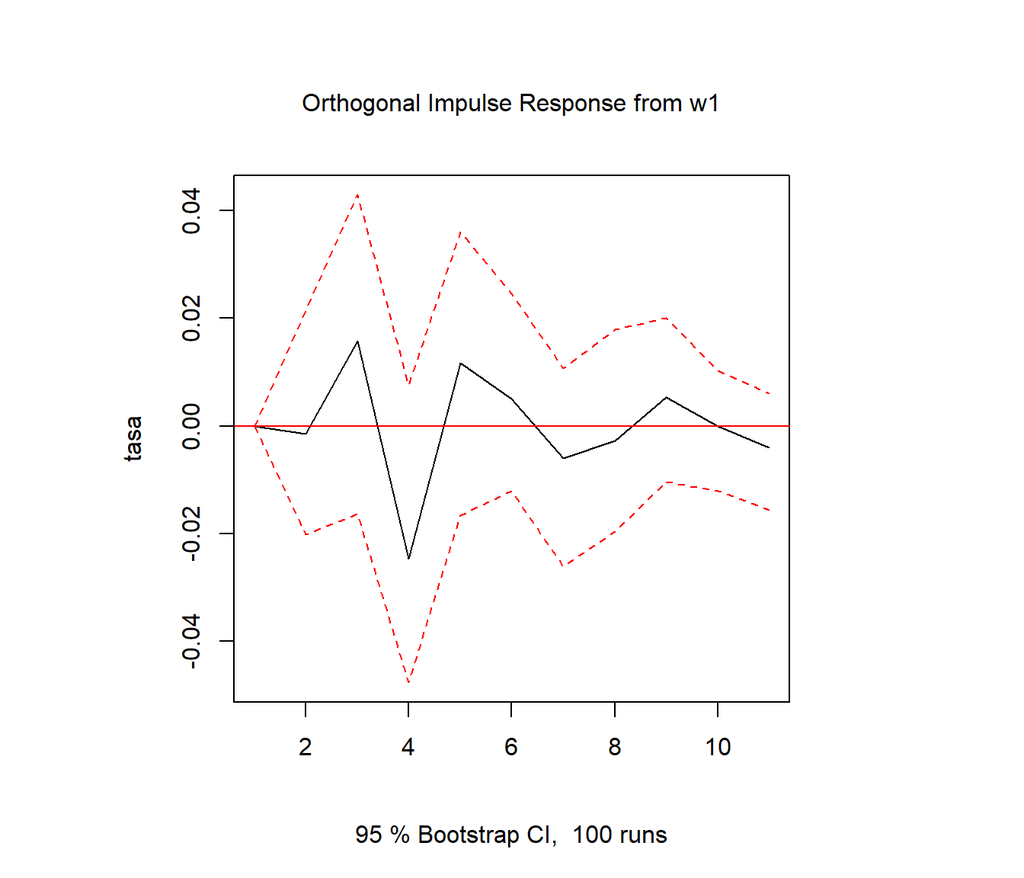

```r
x11()
modelo.irf<-irf(modelo,impulse="w1", response="tasa")
plot(modelo.irf)
```

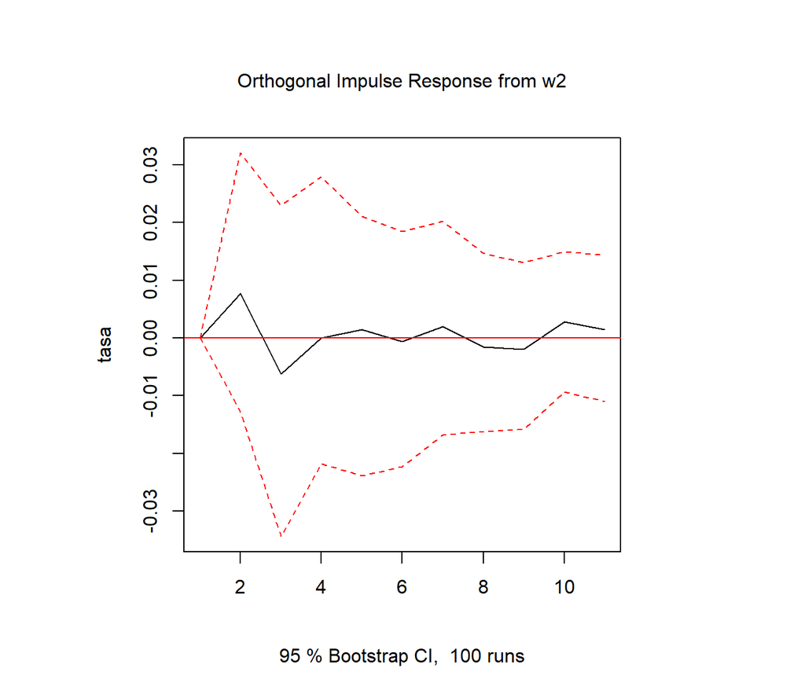

```r
modelo.irf<-irf(modelo,impulse="w2", response="tasa")
plot(modelo.irf)
```

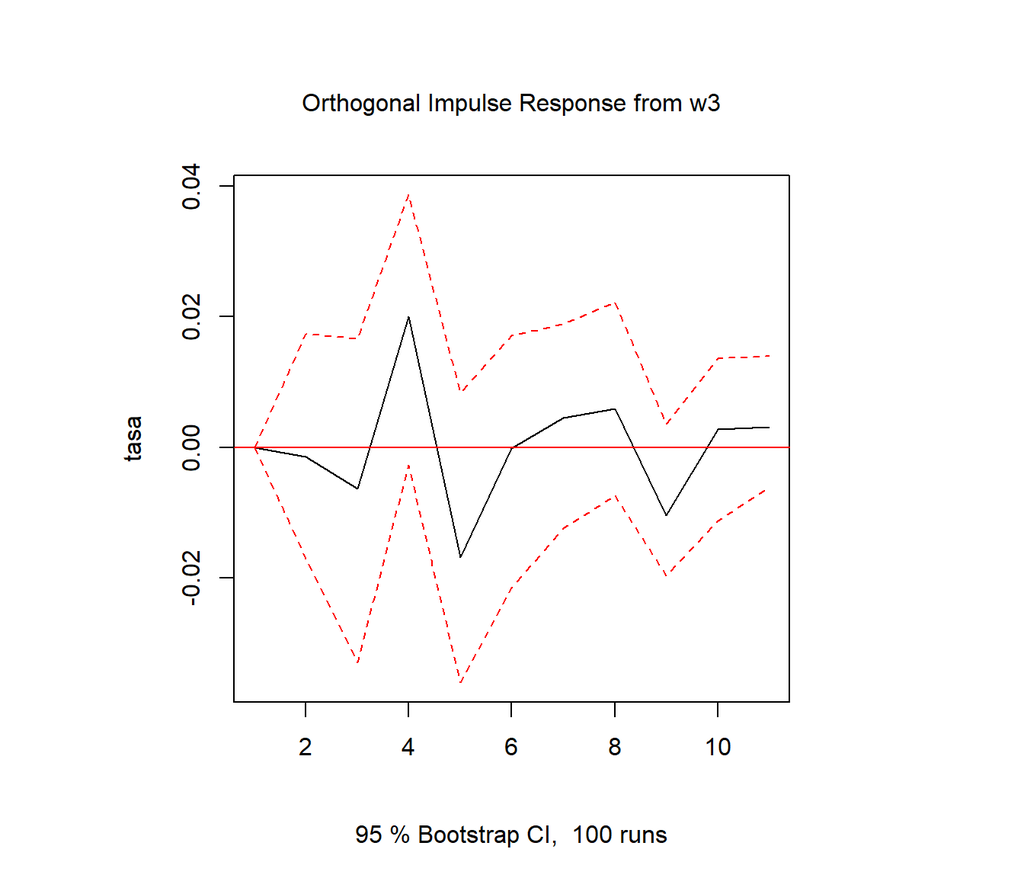

```r
modelo.irf<-irf(modelo,impulse="w3", response="tasa")
plot(modelo.irf)
```

## Modelo 3

```r
  Clasificador1_2 <-  Clasificador1
  Clasificador1_2$fecha <- Clasificador1_2$fecha %>% as.character()
  base22_2<- base22 %>% filter(DATE>="2004-11-17" &DATE<"2009-08-19")
  Clasificador1_2 <-  Clasificador1_2%>% filter(fecha>="2004-11-17" &fecha<="2009-08-19")
  tasa <- ((base22_2$DESPUES/100)-(base22_2$ANTES/100))/(base22_2$ANTES/100)
  series <- cbind(tasa, Clasificador1_2[,3:5])
  #ts.plot(series, xlab="Tiempo",col=c(1,2))
```

SelecciÃ³n del LAG

```r
  VARselect(diff(as.matrix(series)),lag.max=10,type="const")
```

```
## $selection
## AIC(n)  HQ(n)  SC(n) FPE(n)
##      9      9      1     10
##
## $criteria
##                    1             2             3             4
## AIC(n) -4.712582e+01 -4.707803e+01 -4.683902e+01 -4.684164e+01
## HQ(n)  -4.682506e+01 -4.653667e+01 -4.605705e+01 -4.581907e+01
## SC(n)  -4.631482e+01 -4.561824e+01 -4.473043e+01 -4.408426e+01
## FPE(n)  3.429493e-21  3.668094e-21  4.893399e-21  5.375660e-21
##                    5             6             7             8
## AIC(n) -4.683396e+01 -4.673109e+01 -4.730869e+01 -4.781997e+01
## HQ(n)  -4.557079e+01 -4.522731e+01 -4.556430e+01 -4.583498e+01
## SC(n)  -4.342778e+01 -4.267611e+01 -4.260491e+01 -4.246740e+01
## FPE(n)  6.409062e-21  9.359704e-21  8.186690e-21  1.015495e-20
##                    9            10
## AIC(n) -4.905304e+01           NaN
## HQ(n)  -4.682744e+01           NaN
## SC(n)  -4.305167e+01           NaN
## FPE(n)  1.067743e-20 -8.381684e-36
```

```r
  #ts.plot(diff(as.matrix(series)),xlab="Tiempo", col=c(1,2,3,4))
```

1.2. Paso 2: EstimaciÃ³n del Modelo VAR

```r
  modelo<-VAR(diff(as.matrix(series)),p=2,type=c("const"))
  summary(modelo,equation="tasa")
```

```
##
## VAR Estimation Results:
## =========================
## Endogenous variables: tasa, w1, w2, w3
## Deterministic variables: const
## Sample size: 52
## Log Likelihood: 965.211
## Roots of the characteristic polynomial:
## 0.6827 0.6827 0.629 0.629 0.3618 0.3618 0.3196 0.3196
## Call:
## VAR(y = diff(as.matrix(series)), p = 2, type = c("const"))
##
##
## Estimation results for equation tasa:
## =====================================
## tasa = tasa.l1 + w1.l1 + w2.l1 + w3.l1 + tasa.l2 + w1.l2 + w2.l2 + w3.l2 + const
##
##          Estimate Std. Error t value Pr(>|t|)
## tasa.l1 -0.736812   0.136775  -5.387 2.83e-06 ***
## w1.l1    2.441808   6.751227   0.362   0.7194
## w2.l1    5.273322   3.122797   1.689   0.0985 .
## w3.l1    0.500641   4.048455   0.124   0.9022
## tasa.l2 -0.273428   0.129835  -2.106   0.0411 *
## w1.l2   -2.458961   6.626578  -0.371   0.7124
## w2.l2   -0.485887   3.141562  -0.155   0.8778
## w3.l2    4.830316   4.491280   1.075   0.2882
## const   -0.002243   0.004674  -0.480   0.6338
## ---
## Signif. codes:  0 '***' 0.001 '**' 0.01 '*' 0.05 '.' 0.1 ' ' 1
##
##
## Residual standard error: 0.03061 on 43 degrees of freedom
## Multiple R-Squared: 0.4805,  Adjusted R-squared: 0.3838
## F-statistic: 4.971 on 8 and 43 DF,  p-value: 0.0002131
##
##
##
## Covariance matrix of residuals:
##            tasa         w1         w2         w3
## tasa  9.371e-04 -1.008e-05  1.848e-05  4.006e-06
## w1   -1.008e-05  8.295e-07 -1.268e-06 -1.178e-07
## w2    1.848e-05 -1.268e-06  4.393e-06 -1.004e-06
## w3    4.006e-06 -1.178e-07 -1.004e-06  1.757e-06
##
## Correlation matrix of residuals:
##          tasa       w1      w2       w3
## tasa  1.00000 -0.36148  0.2880  0.09874
## w1   -0.36148  1.00000 -0.6643 -0.09763
## w2    0.28805 -0.66430  1.0000 -0.36147
## w3    0.09874 -0.09763 -0.3615  1.00000
```

1.3. Paso 3: Evaluación del Modelo 1.3.1. Prueba de Estacionariedad (Condición de Estabilidad de los Estimadores)

```r
  roots(modelo)
```

```
## [1] 0.6826996 0.6826996 0.6289609 0.6289609 0.3617651 0.3617651 0.3195535
## [8] 0.3195535
```

```r
  #La comprobaciÃ³n de la estabilidad no indica que nuestro modelo este mal.
```

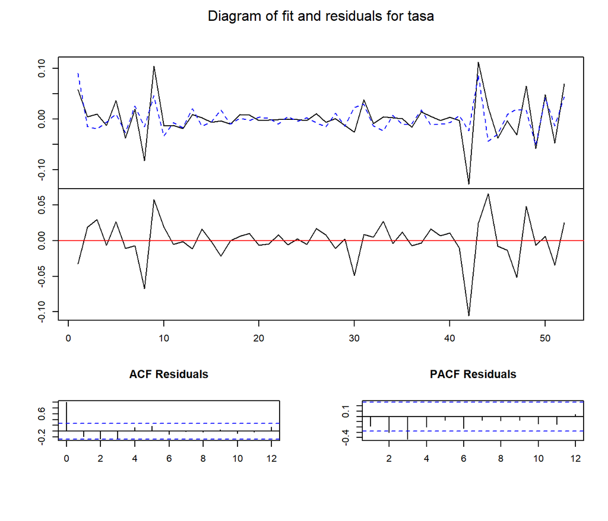

```r
  # 1.3.2. Analisis de Autocorrelacion en los Residuales
  x11()
  plot(modelo, names="tasa")
```

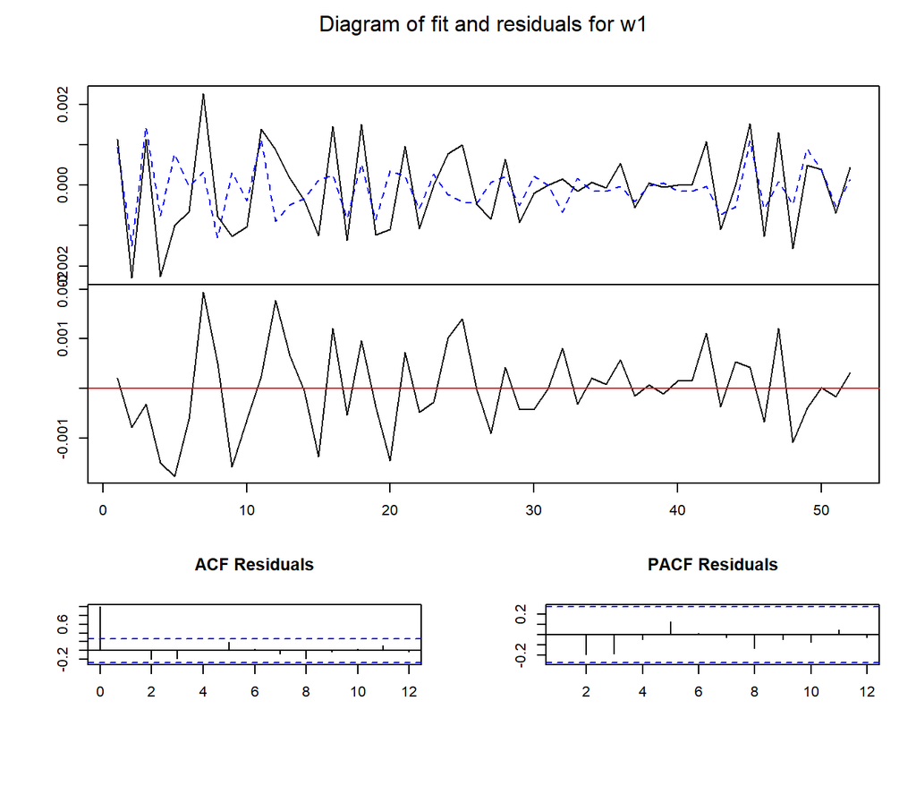

```r
  plot(modelo, names="w1")
```

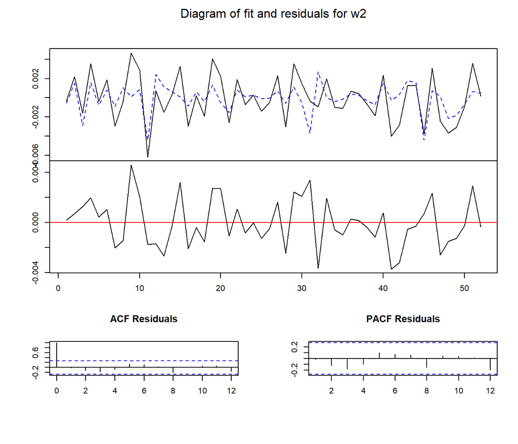

```r
  plot(modelo, names="w2")
```

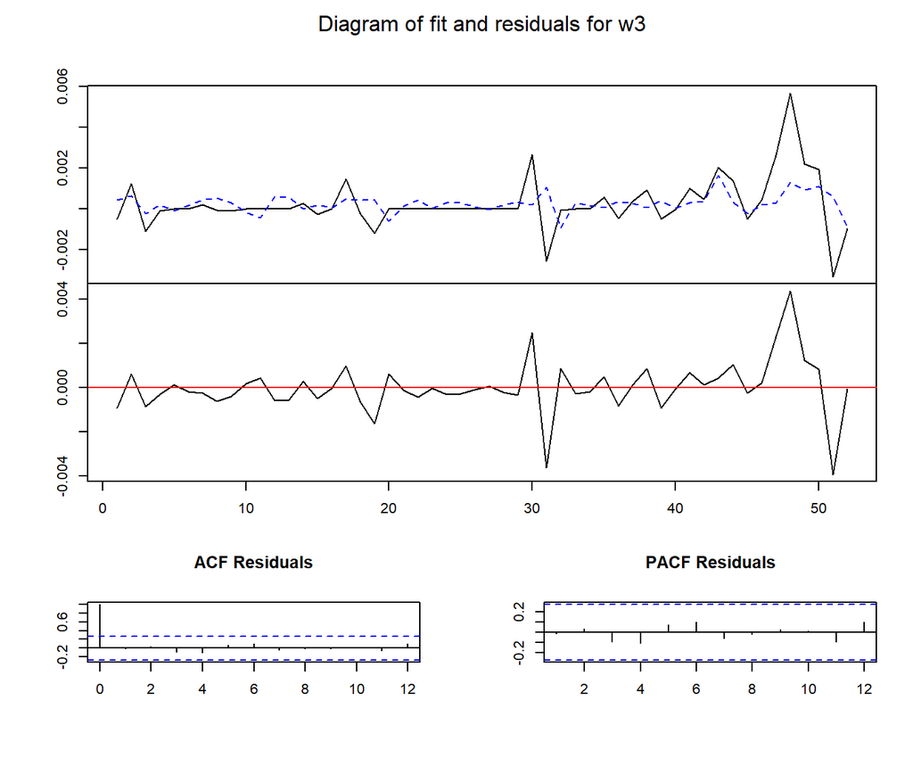

```r
  plot(modelo, names="w3")
```

```r
  # Los grÃ¡ficos muestran claramente la no presencia de correlaciÃ³n serial en los residuos.
```

```r
  # Prueba Portmanteau Multivariada
  serial.test(modelo,lags.pt=10)
```

```
##
##  Portmanteau Test (asymptotic)
##
## data:  Residuals of VAR object modelo
## Chi-squared = 101.41, df = 128, p-value = 0.96
```

```r
  # Prueba de Breusch-Godfrey
  # The null hypothesis is that there is no serial correlation
  serial.test(modelo,lags.bg=10)
```

```
##
##  Portmanteau Test (asymptotic)
##
## data:  Residuals of VAR object modelo
## Chi-squared = 161.96, df = 224, p-value = 0.9994
```

```r
  # Las pruebas confirman la no presencia de autocorrelaciÃ³n en los residuales.

  # 1.3.3. Prueba de Normalidad de los Residuales
  normality.test(modelo, multivariate.only=FALSE)
```

```
## $tasa
##
##  JB-Test (univariate)
##
## data:  Residual of tasa equation
## Chi-squared = 31.701, df = 2, p-value = 1.307e-07
##
##
## $w1
##
##  JB-Test (univariate)
##
## data:  Residual of w1 equation
## Chi-squared = 0.089976, df = 2, p-value = 0.956
##
##
## $w2
##
##  JB-Test (univariate)
##
## data:  Residual of w2 equation
## Chi-squared = 0.99149, df = 2, p-value = 0.6091
##
##
## $w3
##
##  JB-Test (univariate)
##
## data:  Residual of w3 equation
## Chi-squared = 50.849, df = 2, p-value = 9.086e-12
##
##
## $JB
##
##  JB-Test (multivariate)
##
## data:  Residuals of VAR object modelo
## Chi-squared = 53.902, df = 8, p-value = 7.211e-09
##
##
## $Skewness
##
##  Skewness only (multivariate)
##
## data:  Residuals of VAR object modelo
## Chi-squared = 13.148, df = 4, p-value = 0.01057
##
##
## $Kurtosis
##
##  Kurtosis only (multivariate)
##
## data:  Residuals of VAR object modelo
## Chi-squared = 40.754, df = 4, p-value = 3.022e-08
```

```r
  #2. Resumiendo Relaciones Temporales en un VAR
  #2.1. Prueba de Causalidad Granger
  library(magrittr)
  series %>% names
```

```
## [1] "tasa" "w1"   "w2"   "w3"
```

```r
  grangertest(diff(tasa) ~ diff(w1),order=2,data=series)
```

```
## Granger causality test
##
## Model 1: diff(tasa) ~ Lags(diff(tasa), 1:2) + Lags(diff(w1), 1:2)
## Model 2: diff(tasa) ~ Lags(diff(tasa), 1:2)
##   Res.Df Df      F Pr(>F)
## 1     47
## 2     49 -2 1.0014 0.3751
```

```r
  grangertest(diff(tasa) ~ diff(w2),order=2,data=series)
```

```
## Granger causality test
##
## Model 1: diff(tasa) ~ Lags(diff(tasa), 1:2) + Lags(diff(w2), 1:2)
## Model 2: diff(tasa) ~ Lags(diff(tasa), 1:2)
##   Res.Df Df      F  Pr(>F)
## 1     47
## 2     49 -2 2.4611 0.09627 .
## ---
## Signif. codes:  0 '***' 0.001 '**' 0.01 '*' 0.05 '.' 0.1 ' ' 1
```

```r
  grangertest(diff(tasa) ~ diff(w3),order=2,data=series)
```

```
## Granger causality test
##
## Model 1: diff(tasa) ~ Lags(diff(tasa), 1:2) + Lags(diff(w3), 1:2)
## Model 2: diff(tasa) ~ Lags(diff(tasa), 1:2)
##   Res.Df Df      F Pr(>F)
## 1     47
## 2     49 -2 0.4557 0.6368
```

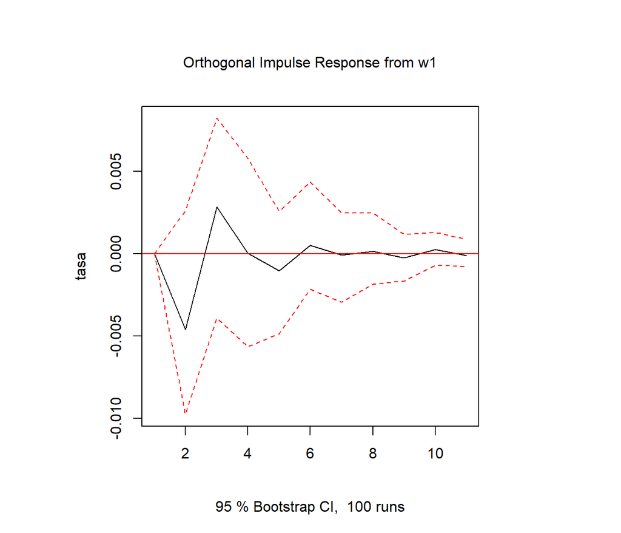

```r
  # Las funciones de impulso respuesta muestran los efectos de los shock en la trayectoria de ajuste de las variables.
  x11()
  modelo.irf<-irf(modelo,impulse="w1", response="tasa")
  plot(modelo.irf)
```

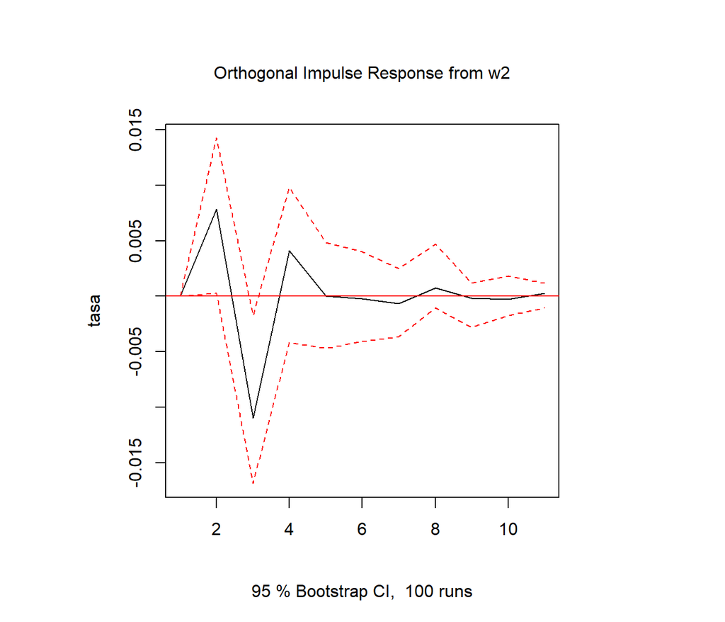

```r
  modelo.irf<-irf(modelo,impulse="w2", response="tasa")
  plot(modelo.irf)
```

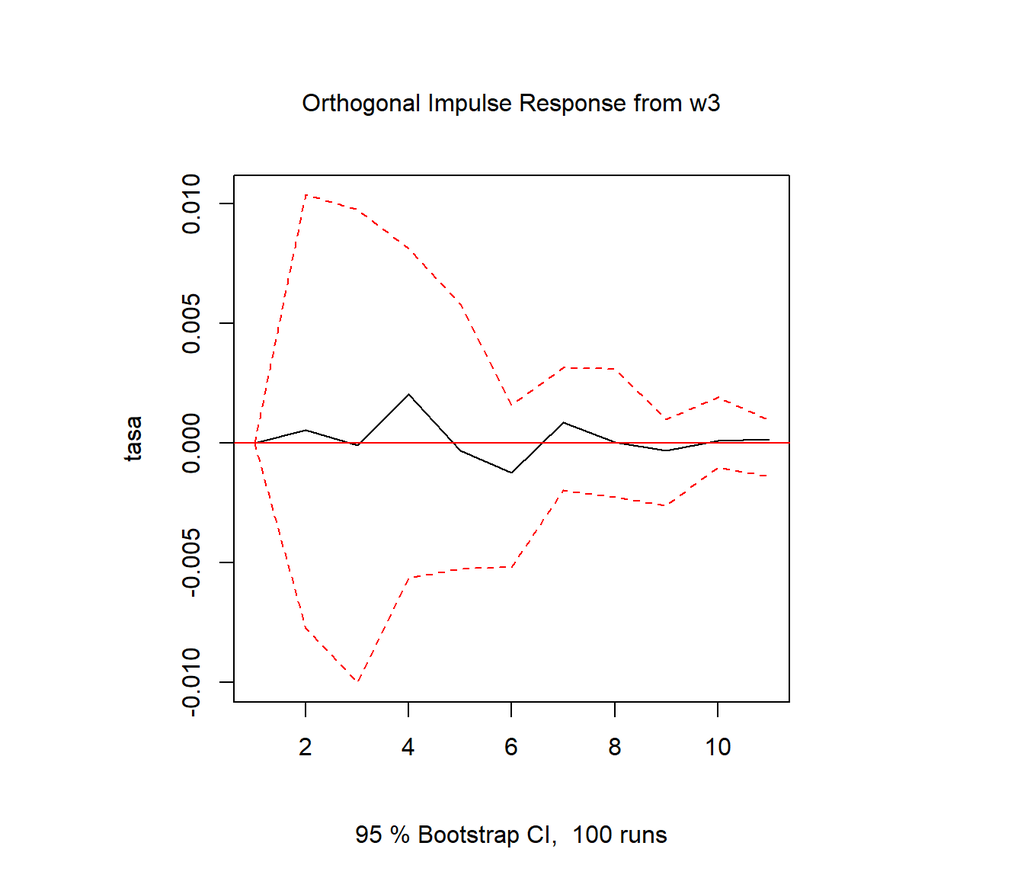

```r
  modelo.irf<-irf(modelo,impulse="w3", response="tasa")
  plot(modelo.irf)
```

## Modelo 4

post-crisis

```r
  Clasificador1_3 <-  Clasificador1
  Clasificador1_3$fecha <- Clasificador1_3$fecha %>% as.character()
  base22_3<- base22 %>% filter(DATE>="2009-09-23" &DATE<"2014-02-19")
  Clasificador1_3 <-  Clasificador1_3%>% filter(fecha>="2009-09-23" &fecha<="2014-02-19")

  tasa <- ((base22_3$DESPUES/100)-(base22_3$ANTES/100))/(base22_3$ANTES/100)
  series <- cbind(tasa, Clasificador1_3[,3:5])
  #ts.plot(series, xlab="Tiempo",col=c(1,2))
```

SelecciÃ³n del LAG

```r
  VARselect(diff(as.matrix(series)),lag.max=10,type="const")
```

```
## $selection
## AIC(n)  HQ(n)  SC(n) FPE(n)
##      9      1      1     10
##
## $criteria
##                    1             2             3             4
## AIC(n) -4.837919e+01 -4.830903e+01 -4.778719e+01 -4.783906e+01
## HQ(n)  -4.807589e+01 -4.776310e+01 -4.699862e+01 -4.680785e+01
## SC(n)  -4.755173e+01 -4.681960e+01 -4.563579e+01 -4.502569e+01
## FPE(n)  9.798431e-22  1.074916e-21  1.917563e-21  2.037618e-21
##                    5             6             7             8
## AIC(n) -4.737709e+01 -4.751909e+01 -4.819758e+01 -4.838586e+01
## HQ(n)  -4.610324e+01 -4.600260e+01 -4.643845e+01 -4.638410e+01
## SC(n)  -4.390175e+01 -4.338178e+01 -4.339830e+01 -4.292461e+01
## FPE(n)  3.941837e-21  4.755082e-21  4.152956e-21  8.703848e-21
##                    9         10
## AIC(n) -5.023909e+01        NaN
## HQ(n)  -4.799469e+01        NaN
## SC(n)  -4.411587e+01        NaN
## FPE(n)  8.228622e-21 -7.579e-67
```

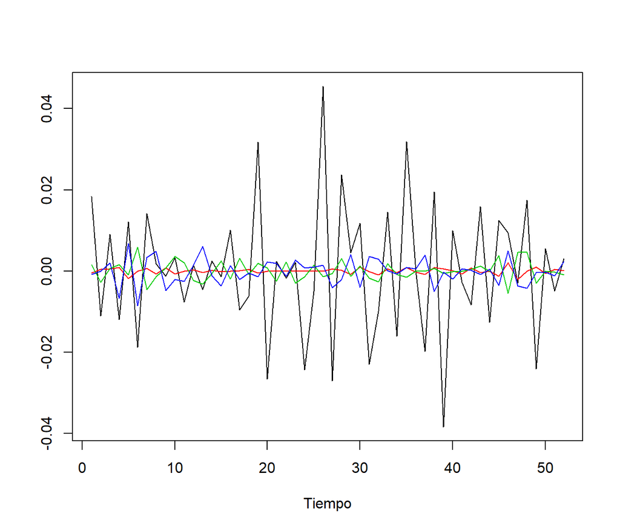

```r
  ts.plot(diff(as.matrix(series)),xlab="Tiempo", col=c(1,2,3,4))
```

1.2. Paso 2: EstimaciÃ³n del Modelo VAR

```r
  modelo<-VAR(diff(as.matrix(series)),p=1,type=c("const"))
  modelo
```

```
##
## VAR Estimation Results:
## =======================
##
## Estimated coefficients for equation tasa:
## =========================================
## Call:
## tasa = tasa.l1 + w1.l1 + w2.l1 + w3.l1 + const
##
##       tasa.l1         w1.l1         w2.l1         w3.l1         const
## -5.546496e-01 -2.034381e+00 -1.309496e-01 -3.560342e-01  2.960478e-05
##
##
## Estimated coefficients for equation w1:
## =======================================
## Call:
## w1 = tasa.l1 + w1.l1 + w2.l1 + w3.l1 + const
##
##       tasa.l1         w1.l1         w2.l1         w3.l1         const
##  2.063699e-03 -4.899761e-01  2.666233e-02 -1.441551e-02  1.994429e-05
##
##
## Estimated coefficients for equation w2:
## =======================================
## Call:
## w2 = tasa.l1 + w1.l1 + w2.l1 + w3.l1 + const
##
##       tasa.l1         w1.l1         w2.l1         w3.l1         const
##  8.062044e-04 -7.174511e-01 -4.437227e-01 -3.708154e-02  9.297143e-05
##
##
## Estimated coefficients for equation w3:
## =======================================
## Call:
## w3 = tasa.l1 + w1.l1 + w2.l1 + w3.l1 + const
##
##       tasa.l1         w1.l1         w2.l1         w3.l1         const
## -0.0042983481  0.5073311903 -0.2329743068 -0.5078518229 -0.0001865885
```

```r
  # A continuacion solicitaremos un resumen de cada ecuaciÃ³n por separado:
  summary(modelo,equation="tasa")
```

```
##
## VAR Estimation Results:
## =========================
## Endogenous variables: tasa, w1, w2, w3
## Deterministic variables: const
## Sample size: 51
## Log Likelihood: 958.693
## Roots of the characteristic polynomial:
## 0.5721 0.5721 0.4576 0.4576
## Call:
## VAR(y = diff(as.matrix(series)), p = 1, type = c("const"))
##
##
## Estimation results for equation tasa:
## =====================================
## tasa = tasa.l1 + w1.l1 + w2.l1 + w3.l1 + const
##
##           Estimate Std. Error t value Pr(>|t|)
## tasa.l1 -0.5546496  0.1212691  -4.574 3.62e-05 ***
## w1.l1   -2.0343814  3.6128131  -0.563    0.576
## w2.l1   -0.1309496  1.5475189  -0.085    0.933
## w3.l1   -0.3560342  1.1130276  -0.320    0.751
## const    0.0000296  0.0019684   0.015    0.988
## ---
## Signif. codes:  0 '***' 0.001 '**' 0.01 '*' 0.05 '.' 0.1 ' ' 1
##
##
## Residual standard error: 0.01403 on 46 degrees of freedom
## Multiple R-Squared: 0.3238,  Adjusted R-squared: 0.265
## F-statistic: 5.507 on 4 and 46 DF,  p-value: 0.001043
##
##
##
## Covariance matrix of residuals:
##            tasa         w1         w2         w3
## tasa  1.969e-04 -2.870e-07  2.325e-06  2.416e-07
## w1   -2.870e-07  4.053e-07 -5.337e-07 -2.285e-07
## w2    2.325e-06 -5.337e-07  5.197e-06 -5.060e-06
## w3    2.416e-07 -2.285e-07 -5.060e-06  8.894e-06
##
## Correlation matrix of residuals:
##           tasa       w1       w2        w3
## tasa  1.000000 -0.03213  0.07268  0.005773
## w1   -0.032128  1.00000 -0.36775 -0.120333
## w2    0.072678 -0.36775  1.00000 -0.744301
## w3    0.005773 -0.12033 -0.74430  1.000000
```

1.3.2. Analisis de Autocorrelacion en los Residuales

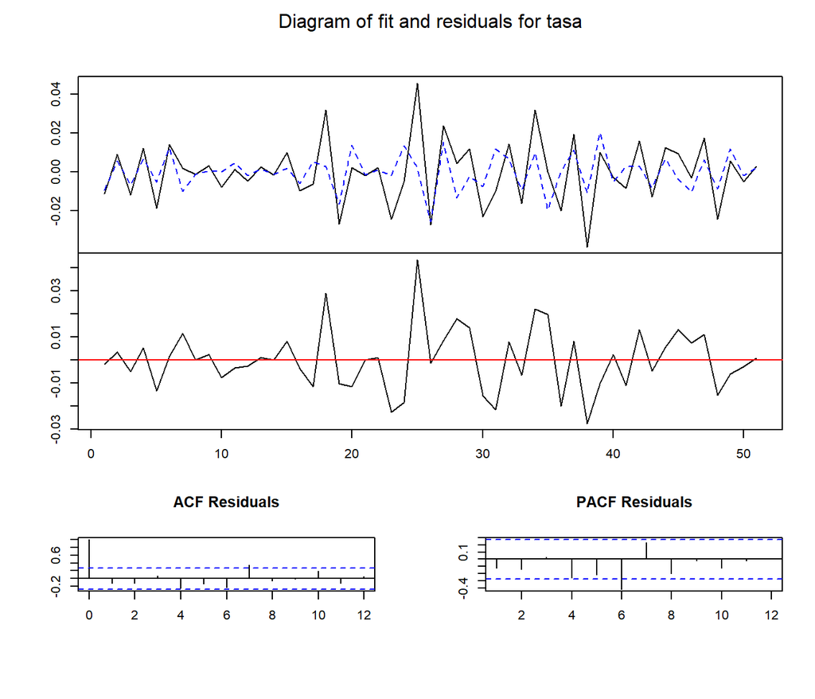

```r
  x11()
  plot(modelo, names="tasa")
```

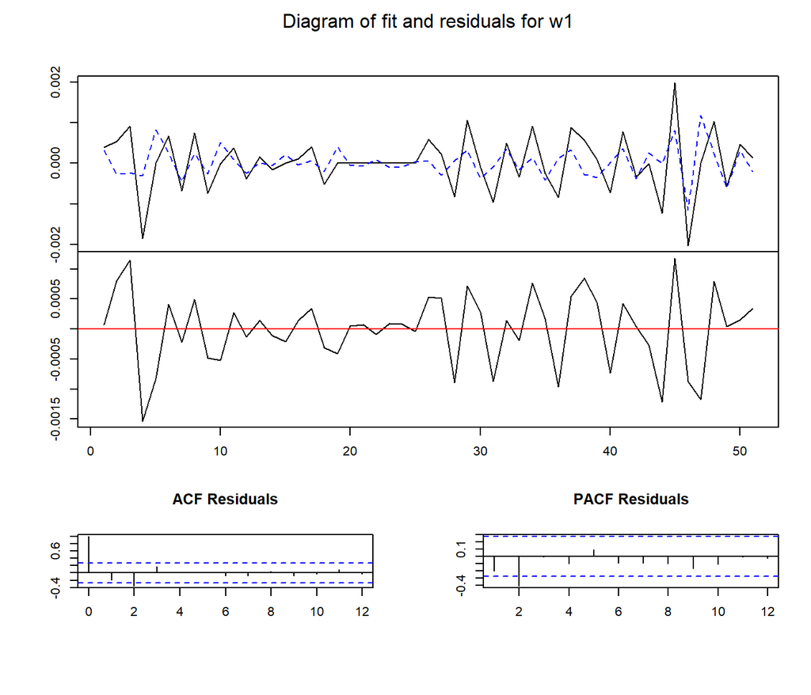

```r
  plot(modelo, names="w1")
```

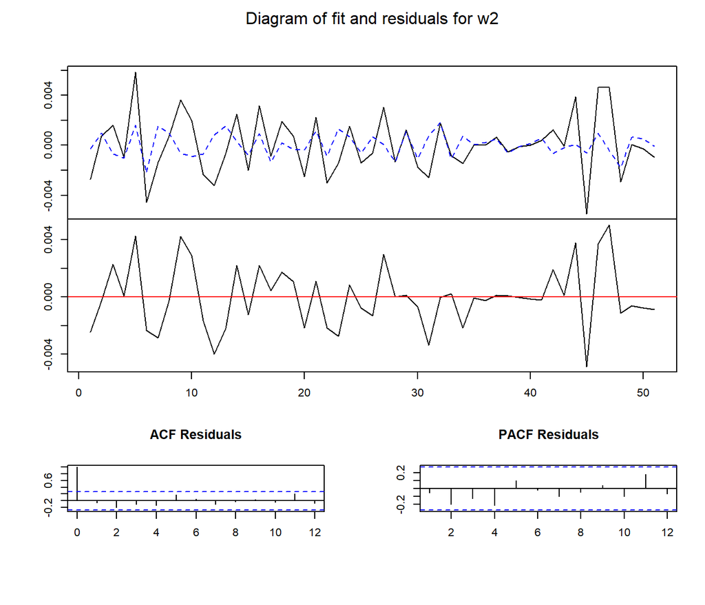

```r
  plot(modelo, names="w2")
```

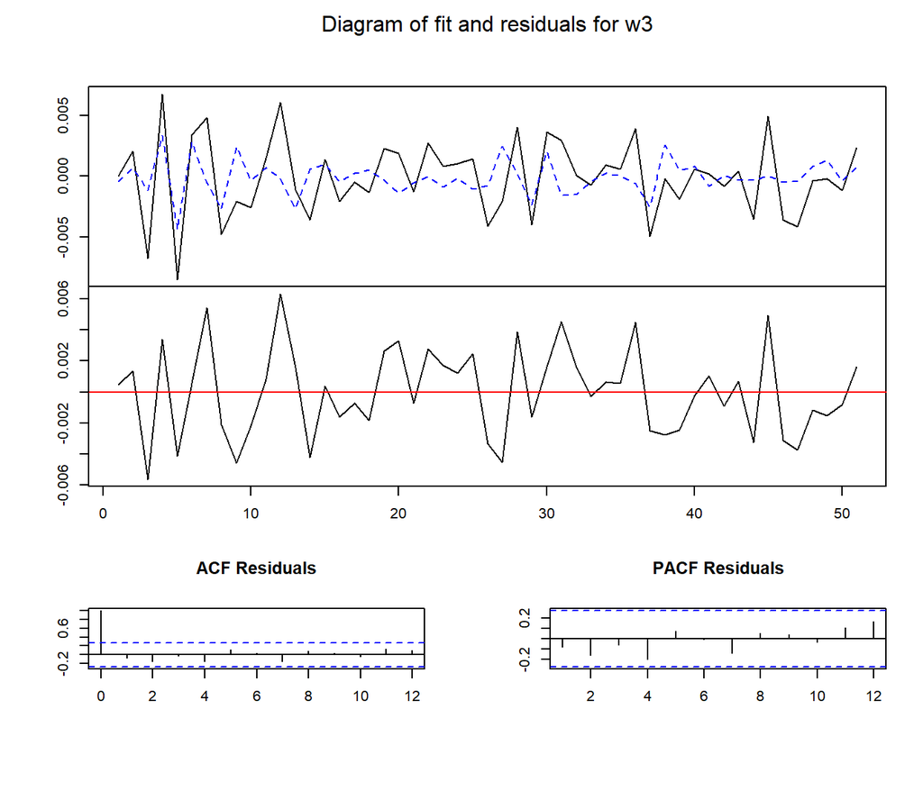

```r
  plot(modelo, names="w3")
```

```r
  # Prueba Portmanteau Multivariada
  serial.test(modelo,lags.pt=10)
```

```
##
##  Portmanteau Test (asymptotic)
##
## data:  Residuals of VAR object modelo
## Chi-squared = 115.52, df = 144, p-value = 0.9611
```

```r
  # Prueba de Breusch-Godfrey
  # The null hypothesis is that there is no serial correlation
  serial.test(modelo,lags.bg=10)
```

```
##
##  Portmanteau Test (asymptotic)
##
## data:  Residuals of VAR object modelo
## Chi-squared = 190.45, df = 240, p-value = 0.992
```

```r
  # Las pruebas confirman la no presencia de autocorrelaciÃ³n en los residuales.

  # 1.3.3. Prueba de Normalidad de los Residuales
  normality.test(modelo, multivariate.only=FALSE)
```

```
## $tasa
##
##  JB-Test (univariate)
##
## data:  Residual of tasa equation
## Chi-squared = 4.6678, df = 2, p-value = 0.09692
##
##
## $w1
##
##  JB-Test (univariate)
##
## data:  Residual of w1 equation
## Chi-squared = 1.5972, df = 2, p-value = 0.45
##
##
## $w2
##
##  JB-Test (univariate)
##
## data:  Residual of w2 equation
## Chi-squared = 0.71371, df = 2, p-value = 0.6999
##
##
## $w3
##
##  JB-Test (univariate)
##
## data:  Residual of w3 equation
## Chi-squared = 1.0874, df = 2, p-value = 0.5806
##
##
## $JB
##
##  JB-Test (multivariate)
##
## data:  Residuals of VAR object modelo
## Chi-squared = 7.2301, df = 8, p-value = 0.512
##
##
## $Skewness
##
##  Skewness only (multivariate)
##
## data:  Residuals of VAR object modelo
## Chi-squared = 4.1424, df = 4, p-value = 0.3871
##
##
## $Kurtosis
##
##  Kurtosis only (multivariate)
##
## data:  Residuals of VAR object modelo
## Chi-squared = 3.0877, df = 4, p-value = 0.5433
```

2. Resumiendo Relaciones Temporales en un VAR 2.1. Prueba de Causalidad Granger

```r
  grangertest(diff(tasa) ~ diff(w1),order=2,data=series)
```

```
## Granger causality test
##
## Model 1: diff(tasa) ~ Lags(diff(tasa), 1:2) + Lags(diff(w1), 1:2)
## Model 2: diff(tasa) ~ Lags(diff(tasa), 1:2)
##   Res.Df Df      F Pr(>F)
## 1     45
## 2     47 -2 0.1376 0.8718
```

```r
  grangertest(diff(tasa) ~ diff(w2),order=2,data=series)
```

```
## Granger causality test
##
## Model 1: diff(tasa) ~ Lags(diff(tasa), 1:2) + Lags(diff(w2), 1:2)
## Model 2: diff(tasa) ~ Lags(diff(tasa), 1:2)
##   Res.Df Df    F Pr(>F)
## 1     45
## 2     47 -2 0.14 0.8698
```

```r
  grangertest(diff(tasa) ~ diff(w3),order=2,data=series)
```

```
## Granger causality test
##
## Model 1: diff(tasa) ~ Lags(diff(tasa), 1:2) + Lags(diff(w3), 1:2)
## Model 2: diff(tasa) ~ Lags(diff(tasa), 1:2)
##   Res.Df Df      F Pr(>F)
## 1     45
## 2     47 -2 0.0936 0.9108
```

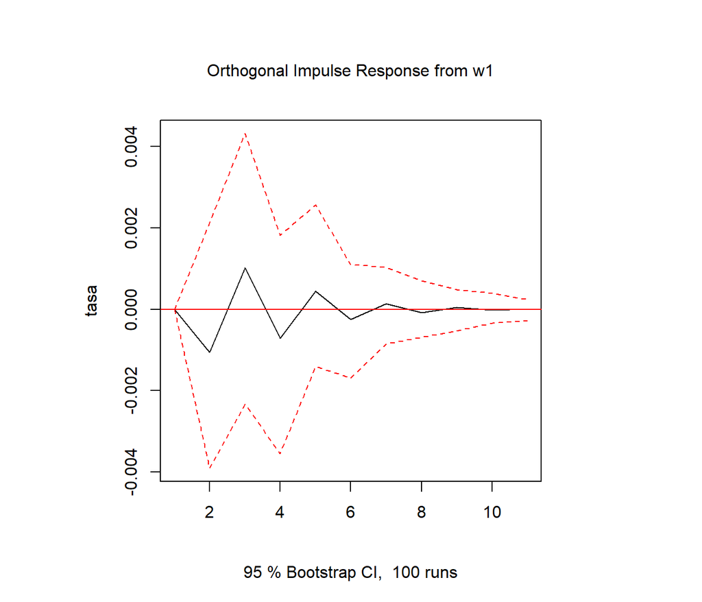

```r
  # Las funciones de impulso respuesta muestran los efectos de los shock en la trayectoria de ajuste de las variables.
  x11()
  modelo.irf<-irf(modelo,impulse="w1", response="tasa")
  plot(modelo.irf)
```

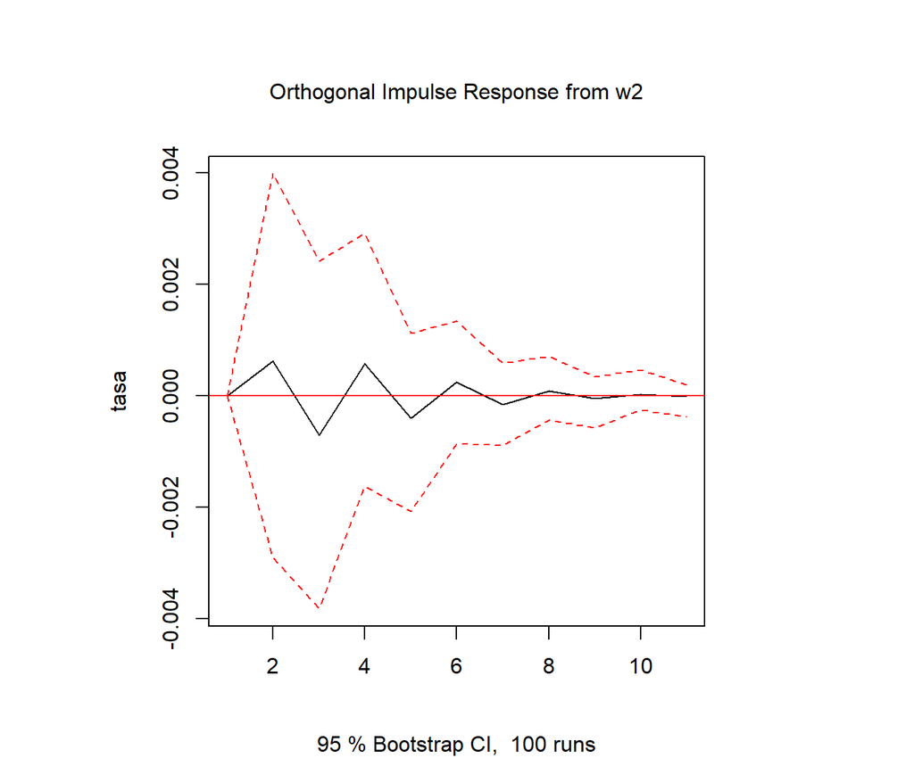

```r
  modelo.irf<-irf(modelo,impulse="w2", response="tasa")
  plot(modelo.irf)
```

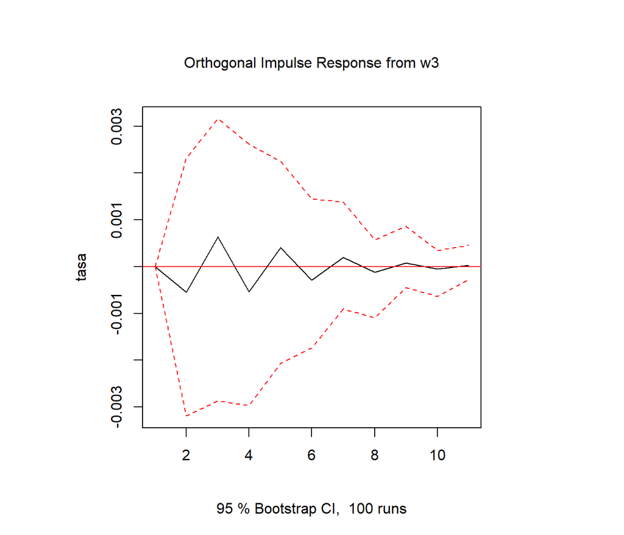

```r
  modelo.irf<-irf(modelo,impulse="w3", response="tasa")
  plot(modelo.irf)
```